# Chapters 8 and 9 Examples

## ANOVA Example:

We would like to compare the concentration (in ppm) of a particular item in lake water. We have the following samples.

```r
concentration <- c(12.7,  9.2, 10.9,  8.9, 16.4,
                    8.3, 17.2, 19.1, 10.3,
                   20.3, 16.6, 22.7, 25.2, 19.9)

lake <- as.factor(c(rep(1,5), rep(2,4), rep(3,5)))

one <- tibble(concentration, lake)
```

### ANOVA table

```r
one_results <- aov(concentration ~ lake, data = one)
one_table <- summary(aov(concentration ~ lake, data = one))

pander(one_table, style='rmarkdown')
```

Analysis of Variance Model

|  | Df | Sum Sq | Mean Sq | F value | Pr(>F) |
| --- | --- | --- | --- | --- | --- |
| **lake** | 2 | 235.8 | 117.9 | 8.031 | 0.007074 |
| **Residuals** | 11 | 161.5 | 14.68 | NA | NA |

### Hypothesis test

**Hypotheses**

$H_0: \ \mu_1 = \mu_2 = \mu_3$  
$H_1:$ at least one is different

**Test Statistic**

$F_0 = p = 8.0312$.

*p*-value

$p = 0.0071$.

**Rejection Region**

Reject if $p < \alpha$, where $\alpha=0.05$.

**Conclusion and Interpretation**

Reject $H_0$. There is sufficient evidence to suggest that at least one lake has a different concentration.

### ANOVA assumptions

Recall the ANOVA assumptions: residuals have normal distribution with equal variances among the three groups.

#### Variance assumption

```r
one_var <- leveneTest(concentration ~ lake, data = one, center = median)
```

**Hypotheses**

$H_0: \ \sigma_1^2 = \sigma_2^2 = \sigma^2_3$  
$H_1:$ at least one is different

**Test Statistic**

$F_0 = 2$.

*p*-value

$p = 0.182$.

**Rejection Region**

Reject if $p < \alpha$, where $\alpha=0.05$.

**Conclusion and Interpretation**

Fail to reject $H_0$. There is not sufficient evidence to suggest that the variances are unequal.

#### Normality assumption

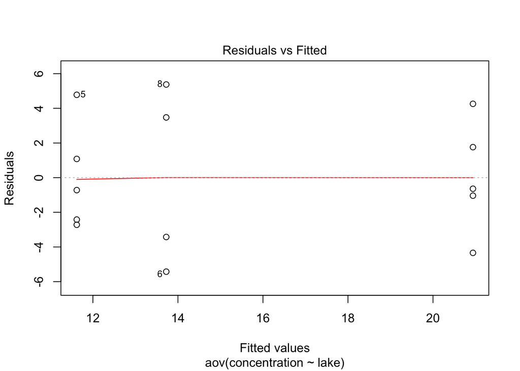

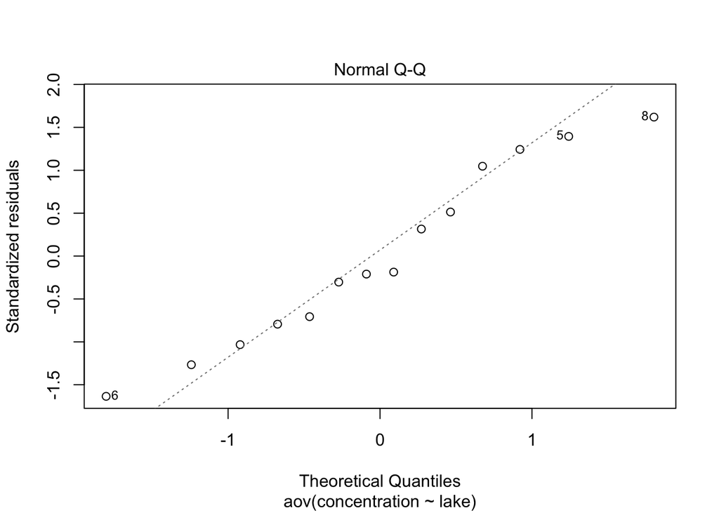

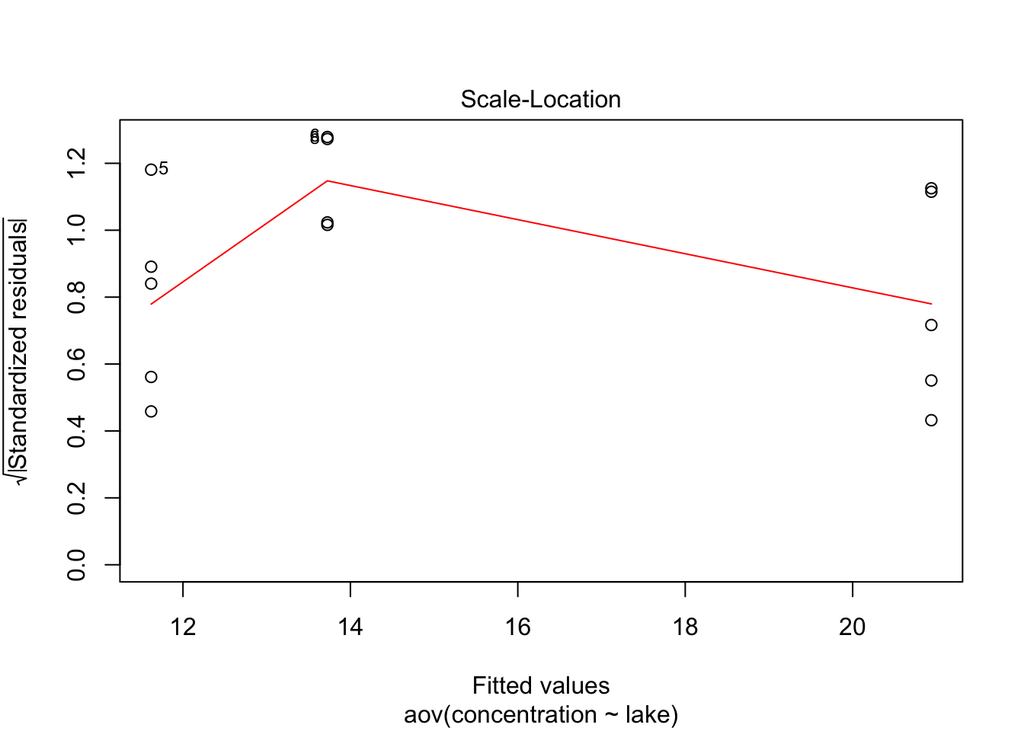

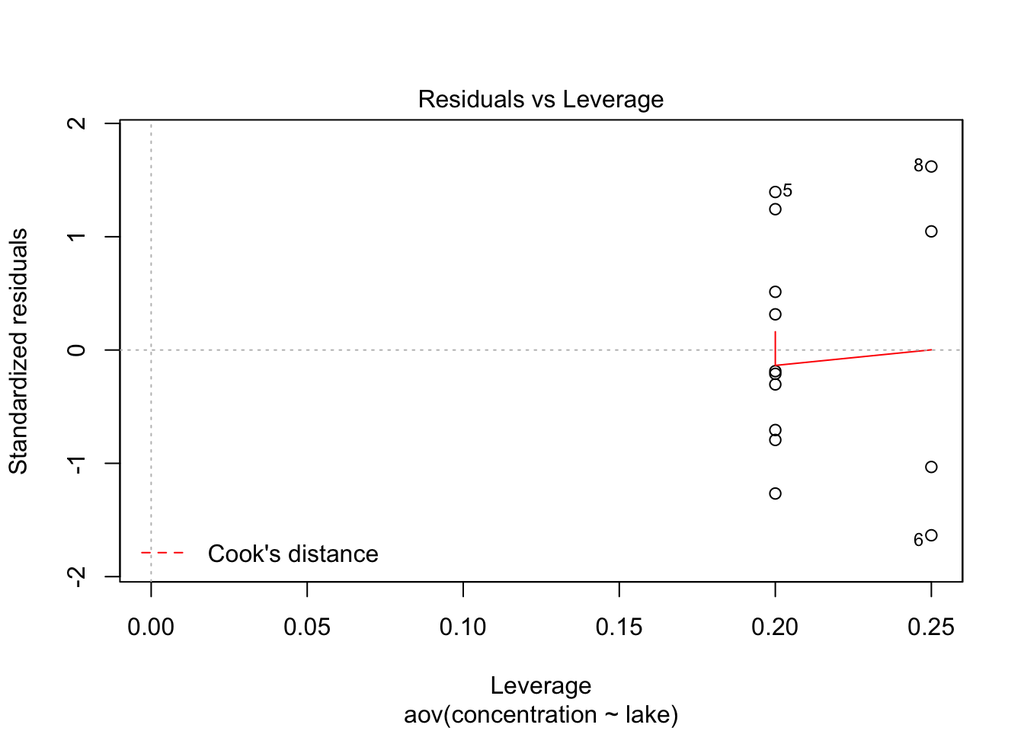

```r
plot(one_results)
```

#### Extra credit opportunity 1:

How do we print only the QQ plot out of the four?

### Bonferroni’s

```r
one_bonf <- pairwise.t.test(one$concentration, one$lake, p.adjust.method = "bonferroni")

# uncomment the next line to view the p-values :)
#one_bonf
```

| Comparison | p-value | Significant? |
| --- | --- | --- |
| 1 vs. 2 | 1.0000 | No |
| 1 vs. 3 | 0.0082 | Yes |
| 2 vs. 3 | 0.0512 | No |

### Tukey’s

```r
one_tukey <- summary(glht(one_results, linfct = mcp(lake = "Tukey")))
```

| Comparison | p-value | Significant? |
| --- | --- | --- |
| 1 vs. 2 | 0.6994 | No |
| 1 vs. 3 | 0.0070 | Yes |
| 2 vs. 3 | 0.0419 | Yes |

### Fisher’s

```r
one_fishers <- pairwise.t.test(one$concentration, one$lake, p.adjust.method = "none")
```

| Comparison | p-value | Significant? |
| --- | --- | --- |
| 1 vs. 2 | 0.4302 | No |
| 1 vs. 3 | 0.0027 | Yes |
| 2 vs. 3 | 0.0171 | Yes |

### Dunnett’s

```r
# Dunnett's uses the first group it sees (numeric or alphabetic) as the control group
# change the order of your factors to change the control group
one_dunnett <- summary(glht(one_results, linfct = mcp(lake = "Dunnett"), base = 1))

one_dunnett
```

```
##
##   Simultaneous Tests for General Linear Hypotheses
##
## Multiple Comparisons of Means: Dunnett Contrasts
##
##
## Fit: aov(formula = concentration ~ lake, data = one)
##
## Linear Hypotheses:
##            Estimate Std. Error t value Pr(>|t|)
## 2 - 1 == 0    2.105      2.570   0.819   0.6407
## 3 - 1 == 0    9.320      2.423   3.846   0.0051 **
## ---
## Signif. codes:  0 '***' 0.001 '**' 0.01 '*' 0.05 '.' 0.1 ' ' 1
## (Adjusted p values reported -- single-step method)
```

[output not shown]

#### Extra credit opportunity 2:

How do we “automate” the tables? I’m thinking that we use R to plug in the *p*-values, but we need a function that determines significance…

#### Extra credit opportunity 3:

How do we do contrasts in R?

## Kruskal-Wallis Example

Because many HMOs either do not cover mental health costs or provide only minimal coverage, ministers and priests often need to provide counseling topersons suffering from mental illness. An interdenominational organization wanted to determine whether the clerics from different religions have different levels of awareness with respect to the causes of mental illness. Three random samples were drawn, one containing ten Methodist ministers, a second containing ten Catholic priests, and a third containing ten Pentecostal ministers. Each of the 30 clerics was then examined, using a standard written test, to measure his or her knowledge about causes of mental illness. The test scores are listed in the table below. Does there appear to be a significant difference in the test scores for the three religions?

```r
score <- c(62, 60, 60, 25, 24, 23, 20, 13, 12,  6,
           62, 62, 24, 24, 22, 20, 19, 10,  8,  8,
           32, 31, 15, 15, 14, 14, 14,  5,  3,  2)

religion <- c(rep("M", 10), rep("C", 10), rep("P", 10))

two <- tibble(score, religion)
```

Let’s perform the Kruskal-Wallis test.

```r
two_results <- kruskal.test(score ~ religion, data = two)
```

**Hypotheses**

$H_0: \ \mbox{M}_1 = \mbox{M}_2 = \mbox{M}_3$  
$H_1:$ at least one is different

**Test Statistic**

$H = 3.25$.

*p*-value

$p = 0.1966$.

**Rejection Region**

Reject if $p < \alpha$, where $\alpha=0.05$.

**Conclusion and Interpretation**

Fail to reject $H_0$. There is not sufficient evidence to suggest that there is a difference between the three religions.

### Kruskal-Wallis post-hoc testing

Note that the formula for the minimum significant difference in R is a little different from the formula that we used. In class, we used the studentized range distribution, however, R uses the following formula
$$\mbox{KW}_{ij} = z_{\alpha/(k(k-1))} \sqrt{\frac{N(N+1)}{12} \left( \frac{1}{n_i} + \frac{1}{n_j} \right)}$$

```r
two_kw <- kruskalmc(score ~ religion, data = two)

pander(two_kw[[3]], style='rmarkdown')
```

|  | obs.dif | critical.dif | difference |
| --- | --- | --- | --- |
| **C-M** | 1.5 | 9.425 | FALSE |
| **C-P** | 5.25 | 9.425 | FALSE |
| **M-P** | 6.75 | 9.425 | FALSE |